# Extended War Report

2026-05-07

# Overview

This is an extended war report for the war **40982** between **Torn Community Garden** and **Nirvana**. Data is presented from the side of **Torn Community Garden**. Link to the official war report can be found [HERE](https://www.torn.com/war.php?step=rankreport&rankID=40982).

## Rewards

War outcome for your faction: **Victory**  
Total hits done: **1397**  
War hits: **1171**  
Non war hits: **226**  
Total respect earned: **11134.46**  
Members contributed: **58/66**

Rewards for your faction:

| Name | Amount | Price |
| --- | --- | --- |
| Melee Cache | 6 | 947.76 M |
| Armor Cache | 2 | 654.91 M |
| Medium Arms Cache | 3 | 651.35 M |

Earnings from caches: **2.25 B**  
Total earnings: **2.25 B**<sup>1</sup>

<sup>1</sup>prices are based on market value or approximate trader prices if market value is unavaliable.

## War Preparation

**NOTE**: Faction Xanax might be different from Prep Xanax due to how personal stats are calculated. In this case, Faction Xanax is more accurate.

Members who **did not stack** energy before war:

|  | Name | Prep_Xanax | Faction_Xanax | Total_Hits |
| --- | --- | --- | --- | --- |
| 1 | -Antheia- | 2 |  | 6 |
| 2 | Beeeeeeeee | 3 | 2 | 33 |
| 3 | Brandy13 | 2 |  | 11 |
| 4 | Captain_Chimkin | 1 |  | 4 |
| 5 | Ch3wie | 3 |  | 38 |
| 6 | Chapelle | 3 | 3 | 24 |
| 7 | Elmoz | 0 |  | 0 |
| 8 | FalconCY | 3 | 3 | 1 |
| 9 | Harleequiin | 1 |  | 30 |
| 10 | Jannerboy | 3 | 3 | 15 |

[output cut: 14 more lines]

Members who **overdosed** during war preparations (but could still have stacked):

|  | Name | Prep_Xanax | Faction_Xanax | Total_Hits |
| --- | --- | --- | --- | --- |
| 1 | BlackLab | 7 | 6 | 53 |
| 2 | Nuit | 7 | 4 | 33 |

Members who **most likely stacked** energy before war (or just used lots of xanax):

|  | Name | Prep_Xanax | Faction_Xanax | Total_Hits |
| --- | --- | --- | --- | --- |
| 1 | Alchemist-Ifrit | 5 | 5 | 17 |
| 2 | Anthrax132 | 4 | 4 | 16 |
| 3 | BakedBeanSoup | 4 | 3 | 14 |
| 4 | BillTheImpaler | 6 | 4 | 19 |
| 5 | Brenadryl | 6 | 6 | 34 |
| 6 | Buzzsmo | 5 | 4 | 6 |
| 7 | ClydeXxX | 4 |  | 6 |
| 8 | D3adpool | 6 |  | 15 |
| 9 | Darnclip | 4 | 4 | 32 |
| 10 | Ezza | 7 | 8 | 26 |

[output cut: 30 more lines]

## Fighting summary

### Top 5

Top 5 by overall contribution %

| Name | Contribution |
| --- | --- |
| Zoot | 6.37 |
| miel | 4.58 |
| Psyp | 4.37 |
| BlackLab | 3.79 |
| Katie | 3.72 |

Top 5 by War hits

| Name | War_Hits |
| --- | --- |
| Zoot | 86 |
| Psyp | 61 |
| miel | 60 |
| mlem | 52 |
| BlackLab | 52 |

Top 5 by Non War hits

| Name | Non_War_Hits |
| --- | --- |
| UnicornKitty | 42 |
| Ch3wie | 29 |
| MrPreyoo | 25 |
| kronfrog | 22 |
| BakedBeanSoup | 10 |

Top 5 by Total hits

| Name | Total_Hits |
| --- | --- |
| Zoot | 89 |
| miel | 64 |
| Psyp | 61 |
| BlackLab | 53 |
| Katie | 52 |

Top 5 by Assists

| Name | Assists |
| --- | --- |
| Psyp | 28 |
| miel | 24 |
| Zoot | 22 |
| Ptidibou | 19 |
| HedgyTrimmer | 18 |

Chain savers - List of people who saved the chain with less than 60 seconds remaining.

```
## [1] "Friendly chain savers:"
```

| Saver | Chain | Time remaining |
| --- | --- | --- |
| MrPreyoo | 703 | 1 |
| Nuit | 556 | 19 |
| Sakura_Yagame | 474 | 8 |
| Sakura_Yagame | 472 | 20 |
| Psyp | 463 | 54 |
| Psyp | 461 | 49 |
| Trang666 | 405 | 38 |
| BlackLab | 394 | 53 |
| Psyp | 391 | 49 |
| Psyp | 385 | 27 |
| Trang666 | 378 | 42 |
| SixtenBlixt | 358 | 14 |
| Katie | 122 | 27 |
| MaSt0rks | 108 | 25 |
| BillTheImpaler | 106 | 60 |
| Zoot | 99 | 25 |
| UnicornKitty | 88 | 37 |
| Ch3wie | 80 | 50 |
| Ch3wie | 79 | 40 |
| Ch3wie | 78 | 26 |
| Ch3wie | 77 | 22 |
| Ch3wie | 76 | 25 |
| Ch3wie | 72 | 25 |
| UnicornKitty | 63 | 14 |
| UnicornKitty | 58 | 14 |
| UnicornKitty | 57 | 23 |
| UnicornKitty | 56 | 14 |
| UnicornKitty | 55 | 14 |
| UnicornKitty | 54 | 15 |
| BakedBeanSoup | 54 | 43 |
| Ch3wie | 53 | 54 |
| Ch3wie | 49 | 44 |
| Ch3wie | 47 | 15 |
| Ch3wie | 46 | 48 |
| UnicornKitty | 44 | 34 |
| Ch3wie | 43 | 35 |
| miel | 42 | 55 |
| miel | 41 | 53 |
| Alchemist-Ifrit | 39 | 45 |
| Ch3wie | 38 | 35 |
| Sottom | 37 | 44 |
| Nuit | 35 | 16 |
| UnicornKitty | 33 | 19 |
| UnicornKitty | 31 | 37 |
| UnicornKitty | 30 | 18 |

```
## [1] "Enemy chain savers:"
```

| Saver | Chain | Time remaining |
| --- | --- | --- |
| kousuke111 | 320 | 33 |
| Jaun | 302 | 59 |
| Flak | 271 | 60 |
| kousuke111 | 225 | 38 |
| Babcia_Jaga | 210 | 14 |
| Robotrinn | 34 | 8 |
|  | 33 | 31 |
| Girbik | 32 | 30 |

### Visual summary

Only including members with non-zero contribution

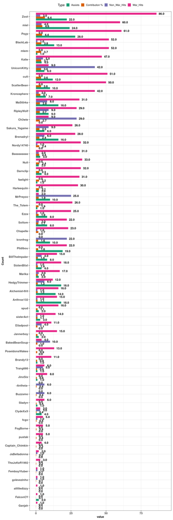

### Respect

Respect earned by each member.<sup>1</sup>  
Total respect earned: **11134.46**  
Total respect lost: **1193.26**  
Net respect change: **9941.2**<sup>2</sup>  
Average respect earned per attack: **7.19**

<sup>1</sup>Chain bonuses are ignored in per-member contributions.  
<sup>2</sup>Respect lost will be 0 if using non-faction API key.

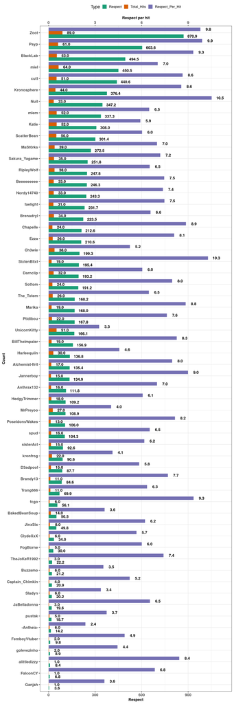

### War Score

Looking at war score gained and lost by each member.  
**The calculations IGNORE chain bonuses in order to better reflect actual contribution rather than landing a lucky hit**  
Total score earned: **9342.1**  
Total score lost: **3855.99**<sup>1</sup>  
Median net score per member: **44.96**<sup>2</sup>

<sup>1</sup>Score lost will be 0 if using non-faction API key.  
<sup>2</sup>Using median instead of mean to avoid extreme values skewing the metric.

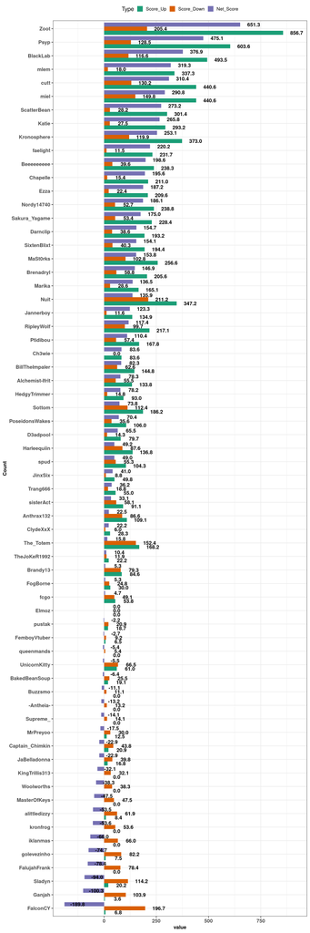

### Slackers

Members who did not meet 1% contribution cutoff

| Name | Contribution |
| --- | --- |
| PoseidonsWakes | 0.93 |
| Trang666 | 0.79 |
| Brandy13 | 0.79 |
| JinxSix | 0.57 |
| fcgo | 0.43 |
| ClydeXxX | 0.43 |
| Sladyn | 0.43 |
| Buzzsmo | 0.43 |
| -Antheia- | 0.43 |
| pustak | 0.36 |
| FogBorne | 0.36 |
| Captain_Chimkin | 0.29 |
| TheJoKeR1992 | 0.21 |
| JaBelladonna | 0.21 |
| golevezinho | 0.14 |
| FemboyVtuber | 0.14 |
| Ganjah | 0.07 |
| FalconCY | 0.07 |
| alittledizzy | 0.07 |
| Supreme_ | 0.00 |
| MasterOfKeys | 0.00 |
| queenmands | 0.00 |
| FalujahFrank | 0.00 |
| iklanmas | 0.00 |
| KingTrillis313 | 0.00 |
| Woolworths | 0.00 |
| Elmoz | 0.00 |

### Energy

Summary of who wasted the most energy and who cost the enemy the most energy.  
Calculated by adding up Losses (and Stalemates, Defends, Escapes, Interrupts) and Defends, the multiplying the number by 25.  
E_Wasted means the member spent X energy on attacks that failed.  
E_Stolen means X energy was wasted by the enemy on attacking the member unsuccessfully.  
You might want to take a closer look at members with high E_Wasted values and remind them to pick fights they can win!

<sup>1</sup> These numbers will be 0 if you are using an API key WITHOUT faction access.

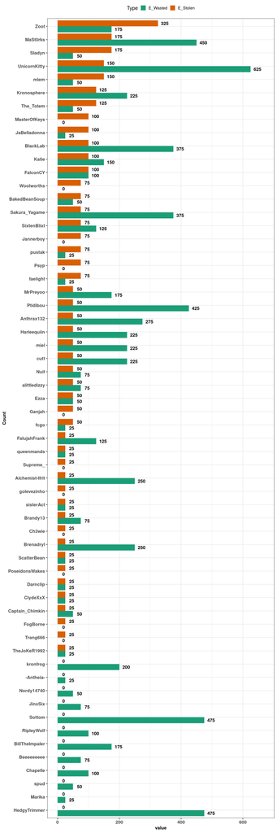

### Full table

Full table with filters and search

|  | Name | Total_Hits | Contribution | War_Hits | Non_War_Hits | Assists | Respect | Respect_Per_Hit | Respect_Lost | Score_Up | Score_Down | Net_Score |
| --- | --- | --- | --- | --- | --- | --- | --- | --- | --- | --- | --- | --- |
| 1 | TheJoKeR1992 | 3 | 0.21 | 3 | 0 | 0 | 22.23 | 7.41 | 5.73 | 22.23 | 11.85 | 10.38 |
| 2 | faelight | 31 | 2.22 | 31 | 0 | 1 | 231.7 | 7.47 | 3.88 | 231.7 | 11.53 | 220.17 |
| 3 | fcgo | 6 | 0.43 | 5 | 1 | 0 | 56.1 | 9.35 | 13.77 | 53.81 | 49.08 | 4.73 |
| 4 | Ganjah | 1 | 0.07 | 1 | 0 | 0 | 3.6 | 3.6 | 27.85 | 3.6 | 103.94 | -100.34 |
| 5 | HedgyTrimmer | 18 | 1.29 | 12 | 6 | 18 | 109.21 | 6.07 | 7.299999999999999 | 93.00999999999999 | 14.84 | 78.17 |
| 6 | Ezza | 26 | 1.86 | 25 | 1 | 8 | 210.61 | 8.1 | 5.94 | 209.6 | 22.37 | 187.23 |
| 7 | Zoot | 89 | 6.37 | 86 | 3 | 22 | 870.87 | 9.79 | 52.48999999999999 | 856.73 | 205.42 | 651.31 |
| 8 | The_Totem | 26 | 1.86 | 26 | 0 | 1 | 168.18 | 6.47 | 39.09 | 168.18 | 152.41 | 15.77 |
| 9 | Marika | 19 | 1.36 | 17 | 2 | 2 | 168.02 | 8.84 | 9 | 165.13 | 28.64 | 136.49 |
| 10 | FalconCY | 1 | 0.07 | 1 | 0 | 2 | 6.85 | 6.85 | 50.29000000000001 | 6.85 | 196.68 | -189.83 |

[output cut: 56 more lines]

## Extra details

### Xanax and refill usage

Xanax and Energy refill usage during the war.

Total Xanax used: **313**  
Xanax costs: **267.06 M**  
Total Refills used: **76**  
Refill costs: **65.8 M**

Drug cost in plot is in millions.

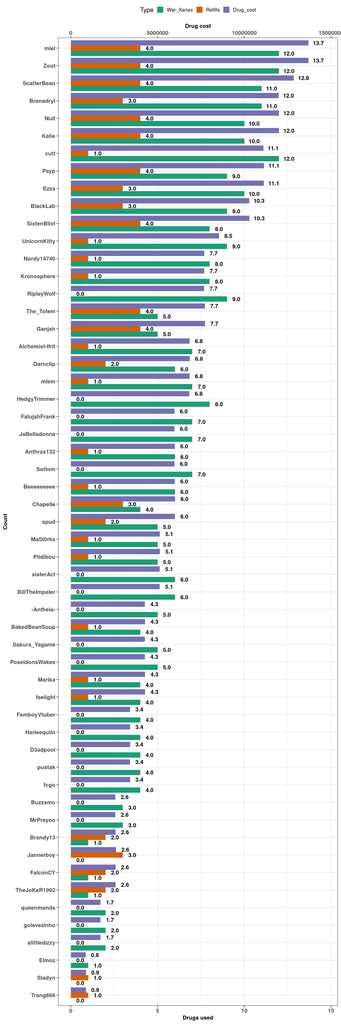

### Booster and can usage

Energy can and Booster usage during the war.

Total Boosters used: **38**  
Booster costs: **470.7 M**  
Total Cans used: **35**  
Can costs: **61.62 M**

All Boosters are assumed to be FHCs and Can price is set to average market value for ALL cans.

Booster cost in plot is in 10s of millions.

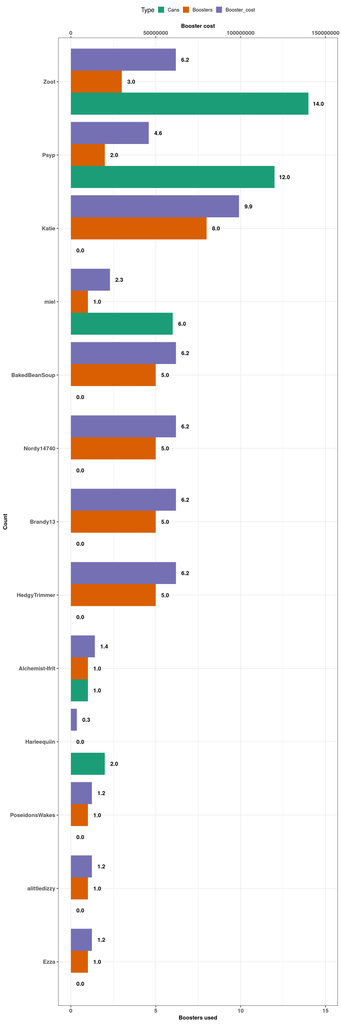

### Armory usage (BETA)

This is a summary of Armory usage during the preparation and war period.  
It can be useful for getting a good idea of how much consumables were used during the war in total.

<sup>1</sup> This section will be empty if you are using an API key WITHOUT faction access.

#### During preparation

```
## [1] "Preparation Armory usage:"
```

|  | Name | ID | action | amount | item | Hours_to_war |
| --- | --- | --- | --- | --- | --- | --- |
| 1 | Ezza | 1727314 | used | 1 | Xanax | 71.82 |
| 2 | cutt | 2944902 | used | 1 | Xanax | 71.78 |
| 3 | cutt | 2944902 | used | 1 | Blood Bag : A+ | 71.69 |
| 4 | kronfrog | 3465089 | used | 1 | First Aid Kit | 71.58 |
| 5 | kronfrog | 3465089 | used | 1 | First Aid Kit | 71.58 |
| 6 | kronfrog | 3465089 | used | 1 | First Aid Kit | 71.58 |
| 7 | kronfrog | 3465089 | used | 1 | First Aid Kit | 71.58 |
| 8 | Alchemist-Ifrit | 3980352 | used | 1 | Bottle of Beer | 71.57 |
| 9 | Alchemist-Ifrit | 3980352 | used | 1 | Bottle of Beer | 71.57 |
| 10 | Alchemist-Ifrit | 3980352 | used | 1 | Bottle of Beer | 71.57 |

[output cut: 1062 more lines]

```
## [1] "Preparation usage totals:"
```

|  | Action | Item | Count |
| --- | --- | --- | --- |
| 1 | used | Bottle of Beer | 448 |
| 2 | used | Bag of Chocolate Kisses | 247 |
| 3 | used | Xanax | 190 |
| 4 | loaned | Tear Gas | 132 |
| 5 | loaned | Smoke Grenade | 110 |
| 6 | loaned | Flash Grenade | 65 |
| 7 | loaned | HEG | 50 |
| 8 | used | First Aid Kit | 41 |
| 9 | used | Blood Bag : A+ | 30 |
| 10 | used | Small First Aid Kit | 23 |

[output cut: 35 more lines]

```
## [1] "Only showing consumables"
```

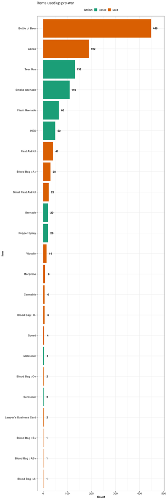

#### During war

```
## [1] "War Armory usage:"
```

|  | Name | ID | action | amount | item | Hours_to_end |
| --- | --- | --- | --- | --- | --- | --- |
| 1 | BlackLab | 4012506 | used | 1 | Blood Bag : A+ | 55.01 |
| 2 | Ptidibou | 3983816 | used | 1 | Blood Bag : A+ | 55.01 |
| 3 | Ptidibou | 3983816 | used | 1 | Blood Bag : A+ | 55.01 |
| 4 | RipleyWolf | 3719564 | used | 1 | Blood Bag : O+ | 55.01 |
| 5 | Sladyn | 3458310 | used | 1 | Blood Bag : A+ | 55.01 |
| 6 | Sladyn | 3458310 | used | 1 | Blood Bag : A+ | 55.01 |
| 7 | Anthrax132 | 3940834 | used | 1 | Blood Bag : O+ | 55 |
| 8 | Anthrax132 | 3940834 | used | 1 | Blood Bag : O+ | 55 |
| 9 | BillTheImpaler | 3683008 | used | 1 | Small First Aid Kit | 55 |
| 10 | RipleyWolf | 3719564 | used | 1 | Blood Bag : O+ | 55 |

[output cut: 1696 more lines]

```
## [1] "War usage totals:"
```

|  | Action | Item | Count |
| --- | --- | --- | --- |
| 1 | used | Blood Bag : A+ | 392 |
| 2 | used | Bottle of Beer | 209 |
| 3 | used | Blood Bag : O+ | 185 |
| 4 | loaned | Smoke Grenade | 181 |
| 5 | used | Bag of Chocolate Kisses | 164 |
| 6 | used | Small First Aid Kit | 143 |
| 7 | used | First Aid Kit | 140 |
| 8 | loaned | Flash Grenade | 126 |
| 9 | used | Morphine | 109 |
| 10 | used | Xanax | 90 |

[output cut: 28 more lines]

```
## [1] "Only showing consumables"
```

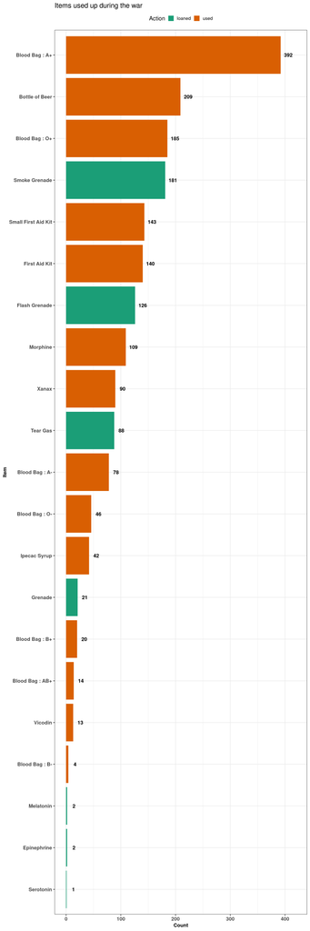

### Activity

Member activity during the war in hours.

```
## [1] "Correlation between activity and contribution:"
```

```
## [1] 0.71
```

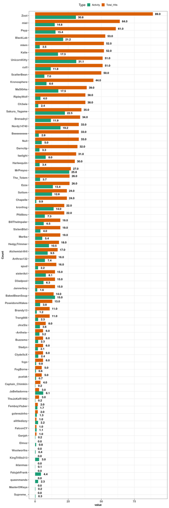

### Hospital

Summary of times hospitalized during the war

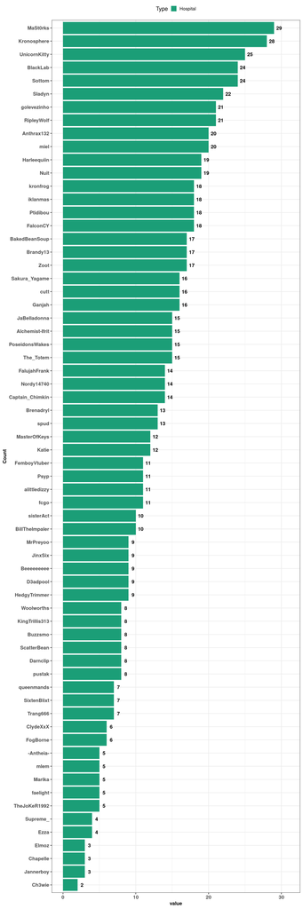

### Full table

|  | Name | War_Xanax | Refills | Boosters | Cans | Drug_cost | Booster_cost | Activity | Hospital |
| --- | --- | --- | --- | --- | --- | --- | --- | --- | --- |
| 1 | TheJoKeR1992 | 1 | 2 | 0 | 0 | 2584762 | 0 | 0.2 | 5 |
| 2 | faelight | 4 | 1 | 0 | 0 | 4278623 | 0 | 7.99 | 5 |
| 3 | fcgo | 4 | 0 | 0 | 0 | 3412848 | 0 | 0.77 | 11 |
| 4 | Ganjah | 5 | 4 | 0 | 0 | 7729160 | 0 | 0.2 | 16 |
| 5 | HedgyTrimmer | 8 | 0 | 5 | 0 | 6825696 | 61933660 | 10.52 | 9 |
| 6 | Ezza | 10 | 3 | 1 | 0 | 11129445 | 12386732 | 13.43 | 4 |
| 7 | Zoot | 12 | 4 | 3 | 14 | 13701644 | 61809389.33 | 30.82 | 17 |
| 8 | The_Totem | 5 | 4 | 0 | 0 | 7729160 | 0 | 3.68 | 15 |
| 9 | Marika | 4 | 1 | 0 | 0 | 4278623 | 0 | 5.36 | 5 |
| 10 | FalconCY | 1 | 2 | 0 | 0 | 2584762 | 0 | 1.15 | 18 |

[output cut: 56 more lines]

## AI summary (BETA)

This is an experimental portion of the report - an overview of the war generated by AI.  
When looking at this section, keep that in mind and take the results with a grain of salt.  
Before taking any actions that might impact faction members mentioned in this summary, double-check that there are no mistakes or missed key details.

## Post-War Debrief

### 1) Overall Faction Performance

The faction produced a **very strong offensive war** with multiple high-volume hitters and several standout point generators. The war was not merely “busy” — it was largely **productive**, with a clear core of members converting activity into meaningful war hits and score gain.

**Participation / roster efficiency**

**Net_Score efficiency**

- The faction’s best performers generated large positive Net_Score totals, especially:
  - **Zoot (+651.31)**
  - **Psyp (+475.06)**
  - **miel (+290.78)**
  - **Kronosphere (+253.14)**
  - **BlackLab (+376.86)**
  - **cutt (+310.41)**
- However, there were also several members with **significant negative Net_Score**, pulling efficiency down:
  - **FalconCY (-189.83)**
  - **Ganjah (-100.34)**
  - **Sladyn (-94.01)**
  - **kronfrog (-53.62)**
  - **Woolworths (-38.34)**
  - **MasterOfKeys (-47.45)**
  - **iklanmas (-65.96)**

**Energy efficiency**

- Overall offensive volume was strong, but energy efficiency was uneven.
- Several members converted activity into high hit counts with strong score gain, while others burned energy with little impact or even net loss.
- This suggests the faction won through **elite execution at the top**, not uniform efficiency across the roster.

### 2) Team Issues & Strategic Bottlenecks

#### A. Energy waste was a major bottleneck

A number of members posted notable **E_Wasted** totals without matching war impact:

- **HedgyTrimmer (475 E_Wasted)** — very high waste, though offset by good score production.
- **Zoot (175 E_Wasted)** — acceptable only because output was enormous.
- **FalconCY (100 E_Wasted)** — severe inefficiency for just 1 war hit.
- **UnicornKitty (625 E_Wasted)** — one of the most concerning waste profiles in the war.
- **BakedBeanSoup (50 E_Wasted)**, **MrPreyoo (175 E_Wasted)**, **kronfrog (200 E_Wasted)** also indicate poor conversion.

This points to a systemic issue: **too many attacks were launched into bad targets, bad timing windows, or poor finishing opportunities**.

#### B. Too many members were low-output or impact-negative

Several players had activity, hits, or hospital presence but little meaningful war contribution:

- **MasterOfKeys**: 0 war hits, 12 hospitalizations, 100 E_Stolen, but no positive output.
- **iklanmas**: 18 hospitalizations, 0 war hits, 0 activity impact.
- **Ganjah**: 16 hospitalizations, -100.34 Net_Score.
- **FalconCY**: 18 hospitalizations, 100 E_Wasted, -189.83 Net_Score.
- **Supreme_** and **Woolworths**: near-zero war contribution despite being on roster.

These are the kinds of profiles that force the core to carry the war.

#### C. Finishing discipline was inconsistent

Mugging is not ideal unless it is the correct war-finisher. Several members had unnecessary Mugged counts:

- **Zoot (1)**
- **HedgyTrimmer (4)**
- **Ezza (0, clean)**
- **Katie (2)**
- **Chapelle (2)**
- **miel (2)**
- **D3adpool (4)**
- **Harleequiin (0, clean)**

Mugging volume by itself is not always bad, but paired with misses and waste it suggests **target selection and end-state discipline need improvement**.

#### D. Some players had high activity but weak conversion

Examples:

- **UnicornKitty**: 31.062 activity, but negative net score and very high E_Wasted.
- **Ch3wie**: solid activity and hits, but unusually large non-war hit count (29), suggesting war focus may have been diluted.
- **kronfrog**: 14.026 activity but no war hits, 22 non-war hits, and large negative impact.

### 3) Individual Highlights — Great Performers

#### Best FairFight values

FairFight around 2.5 is good; higher is exceptional.

- **UnicornKitty: 1.58** — below target
- **Katie: 1.89**
- **cutt: 1.71**
- **Harleequiin: 1.33**
- **Brandy13: 2.17**
- **Sottom: 1.73**
- **The_Totem: 1.50**
- **PoseidonsWakes: 2.46**
- **Nuit: 2.19**
- **fcgo: 2.24**

Best practical efficiency among strong contributors appears to include:

## Bottom Line

The faction won the war through **strong elite performance and solid top-end coordination**, but the data shows clear weaknesses in **energy efficiency, target selection, and roster depth**. The biggest strategic gains will come from:

1. Reducing E_Wasted,
2. Improving war-focused activity from mid/low performers,
3. Emphasizing finish discipline over unnecessary mugging,
4. Concentrating support roles around proven hitters.